# Data Analysis of Simpsons Dialogue

This R Notebook will show one way for working out which of the Simpsons characters is the happiest based on analysing the sentiment of their dialogue from the show. This is more about showing the process than being as accurate as possible, but going through the list at the end, I’m happy with the outcome.

[figure not shown]

Professor Frink

source https://toddwschneider.com/posts/the-simpsons-by-the-data/

The dataset for this comes from kaggle and you can see it here: https://www.kaggle.com/pierremegret/dialogue-lines-of-the-simpsons The dataset is quite small and it has been included with the repo. Make sure you have run the 0_bootstrap.py script at the start to upload the data to the object storage and to set the `STORAGE` envrionment variable.

This project uses the `dplyr`, `sparklyr`, and `ggplot2` packages. There is a weird issue with CRAN and installing `sparklyr` at the moment, so if you install things in the following order, it will work.

```
install.packages("dplyr")
install.packages("tibble")
install.packages("sparklyr")
install.packages("ggplot2")
install.packages("ggthemes")
```

#### Load the libraries

```r
library(sparklyr)
library(dplyr)
library(ggplot2)
library(ggthemes)
```

#### Create the Spark connection

```r
storage <- Sys.getenv("STORAGE")

config <- spark_config()
config$spark.executor.memory <- "4g"
config$spark.executor.instances <- "3"
config$spark.executor.cores <- "4"
config$spark.driver.memory <- "2g"
config$spark.yarn.access.hadoopFileSystems <- storage
sc <- spark_connect(master = "yarn-client", config=config)
```

### Read in the CSV data

The text data is a very simple dataset. Its 2 columns, one for the character, and on for their dialog. Since we know that its 2 columns of `characters` we will set the schema and save spark the trouble of doing it automatically.

```
Miss Hoover,"No, actually, it was a little of both. Sometimes when a disease is in all he magazines and all the news shows, it's nly natural that you think you have it."
Lisa Simpson,Where's Mr. Bergstrom?
Miss Hoover,I don't know. Although I'd sure like to talk to him. He didn't touch my lesson plan. What did he teach you?
Lisa Simpson,That life is worth living.
```

```r
cols = list(
  raw_character_text = "character",
  spoken_words = "character"
)

spark_read_csv(
  sc,
  name = "simpsons_spark_table",
  path = paste(storage,"/datalake/data/sentiment/simpsons_dataset.csv",sep=""),
  infer_schema = FALSE,
  columns = cols,
  header = TRUE
)
```

| raw_character_text | spoken_words |
| --- | --- |
| Miss Hoover | No, actually, it was a little of both. Sometimes when a disease is in all the magazines and all the news shows, it's only natural that you think you have it. |
| Lisa Simpson | Where's Mr. Bergstrom? |
| Miss Hoover | I don't know. Although I'd sure like to talk to him. He didn't touch my lesson plan. What did he teach you? |
| Lisa Simpson | That life is worth living. |
| Edna Krabappel-Flanders | The polls will be open from now until the end of recess. Now, just in case any of you have decided to put any thought into this, we'll have our final statements. Martin? |
| Martin Prince | I don't think there's anything left to say. |
| Edna Krabappel-Flanders | Bart? |
| Bart Simpson | Victory party under the slide! |
| NA | NA |
| Lisa Simpson | Mr. Bergstrom! Mr. Bergstrom! |

[output cut: 990 more lines]

```r
NA
```

The other dataset we will use is the AFINN list. https://github.com/fnielsen/afinn/tree/master/afinn/data its 2 column, the first being the word and the second and integer value for its `valance`.

```
abandon -2
abandoned   -2
abandons    -2
abducted    -2
```

```r
spark_read_csv(
  sc,
  name = "afinn_table",
  path = paste(storage,"/datalake/data/sentiment/AFINN-en-165.txt",sep=""),
  infer_schema = TRUE,
  delimiter = ",",
  header = FALSE
)
```

| V1 | V2 |
| --- | --- |
| abandon | -2 |
| abandoned | -2 |
| abandons | -2 |
| abducted | -2 |
| abduction | -2 |
| abductions | -2 |
| abhor | -3 |
| abhorred | -3 |
| abhorrent | -3 |
| abhors | -3 |

[output cut: 990 more lines]

#### Create local references for the Spark tables.

```r
afinn_table <- tbl(sc, "afinn_table")
afinn_table <- afinn_table %>% rename(word = V1, value = V2)

simpsons_spark_table <- tbl(sc, "simpsons_spark_table")

as.data.frame(head(simpsons_spark_table))
```

| raw_character_text | spoken_words |
| --- | --- |
| Miss Hoover | No, actually, it was a little of both. Sometimes when a disease is in all the magazines and all the news shows, it's only natural that you think you have it. |
| Lisa Simpson | Where's Mr. Bergstrom? |
| Miss Hoover | I don't know. Although I'd sure like to talk to him. He didn't touch my lesson plan. What did he teach you? |
| Lisa Simpson | That life is worth living. |
| Edna Krabappel-Flanders | The polls will be open from now until the end of recess. Now, just in case any of you have decided to put any thought into this, we'll have our final statements. Martin? |
| Martin Prince | I don't think there's anything left to say. |

```r
simpsons_spark_table %>% count()
```

| n |
| --- |
| 158314 |

#### Basic data cleaning

Renaming a column

```r
simpsons_spark_table <-
  simpsons_spark_table %>%
  rename(raw_char = raw_character_text)
```

Droping null / NA values

```r
simpsons_spark_table <-
  simpsons_spark_table %>%
  na.omit()
```

```
* Dropped 26461 rows with 'na.omit' (158314 => 131853)
```

#### Show the changes

```r
simpsons_spark_table %>% group_by(raw_char) %>% count() %>% arrange(desc(n))
```

| raw_char | n |
| --- | --- |
| Homer Simpson | 27850 |
| Marge Simpson | 13172 |
| Bart Simpson | 12995 |
| Lisa Simpson | 10756 |
| C. Montgomery Burns | 3077 |
| Moe Szyslak | 2808 |
| Seymour Skinner | 2385 |
| Ned Flanders | 2056 |
| Grampa Simpson | 1802 |
| Chief Wiggum | 1790 |

[output cut: 990 more lines]

## Text Mining

https://spark.rstudio.com/guides/textmining/

#### Remove punctuation

- mutate can use python.

```r
simpsons_spark_table <-
  simpsons_spark_table %>%
  mutate(spoken_words = regexp_replace(spoken_words, "\'", "")) %>%
  mutate(spoken_words = regexp_replace(spoken_words, "[_\"():;,.!?\\-]", " "))
```

#### Tokenize

```r
simpsons_spark_table <-
  simpsons_spark_table %>%
  ft_tokenizer(input_col="spoken_words",output_col= "word_list")
```

#### Remove stop words

```r
simpsons_spark_table <-
  simpsons_spark_table %>%
  ft_stop_words_remover(input_col = "word_list", output_col = "wo_stop_words")
```

#### Write these to Hive to use later

```r
spark_write_table(simpsons_spark_table,"simpsons_spark_table",mode = "overwrite")
spark_write_table(afinn_table,"afinn_table",mode = "overwrite")
```

```r
sentences <- simpsons_spark_table %>%
  mutate(word = explode(wo_stop_words)) %>%
  select(spoken_words, word) %>%
  filter(nchar(word) > 2) %>%
  compute("simpsons_spark_table")

sentence_values <- sentences %>%
  inner_join(afinn_table) %>%
  group_by(spoken_words) %>%
  summarise(weighted_sum = sum(value))
weighted_sum_summary <- sentence_values %>% sdf_describe(cols="weighted_sum")
```

```
Missing values are always removed in SQL.
Use `SUM(x, na.rm = TRUE)` to silence this warning
```

```r
weighted_sum_summary
```

| summary | weighted_sum |
| --- | --- |
| count | 63568 |
| mean | 0.595551220739995 |
| stddev | 4.032420140957695 |
| min | -77 |
| max | 444 |

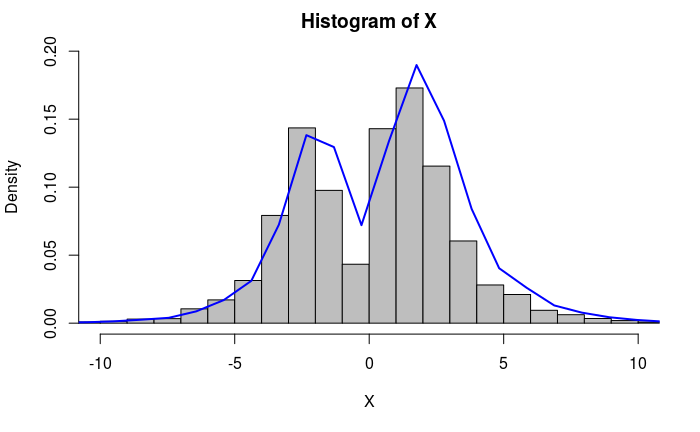

```r
density_plot <- function(X) {
  hist(X, prob=TRUE, col="grey", breaks=500, xlim=c(-10,10), ylim=c(0,0.2))# prob=TRUE for probabilities not counts
  lines(density(X), col="blue", lwd=2) # add a density estimate with defaults

}
density_plot(as.data.frame(sentence_values %>% select(weighted_sum))$weighted_sum)
```

#### Explode that word lists into a single column of word by characters, then find the top 30 characters by number of words.

```r
simpsons_final_words <- simpsons_spark_table %>%  mutate(word = explode(wo_stop_words)) %>%
  select(word, raw_char) %>%
  filter(nchar(word) > 2) %>%
  compute("simpsons_spark_table")

top_chars <- simpsons_final_words %>%
  group_by(raw_char) %>%
  count() %>%
  arrange(desc(n)) %>%
  head(30) %>%
  as.data.frame()

top_chars <- as.vector(top_chars$raw_char)
```

## Sentiment Analysis

```r
happiest_characters <- simpsons_final_words %>%
  filter(raw_char %in% top_chars) %>%
  inner_join(afinn_table) %>%
  group_by(raw_char) %>%
  summarise(weighted_sum = sum(value)/count()) %>%
  arrange(desc(weighted_sum)) %>%
  as.data.frame()
```

```r
happiest_characters
```

| raw_char | weighted_sum |
| --- | --- |
| Lenny Leonard | 0.61735941 |
| Barney Gumble | 0.56373938 |
| Marge Simpson | 0.55525181 |
| Edna Krabappel-Flanders | 0.54779412 |
| Ned Flanders | 0.54519613 |
| Milhouse Van Houten | 0.53899480 |
| Announcer | 0.53465347 |
| Carl Carlson | 0.52827141 |
| Selma Bouvier | 0.48062016 |
| Comic Book Guy | 0.44742729 |

[output cut: 20 more lines]

[figure not shown]

```r
p <-
  ggplot(happiest_characters, aes(reorder(raw_char,weighted_sum), weighted_sum))+
  theme_tufte(base_size=14, ticks=F) +
  geom_col(width=0.75, fill = "grey") +
  theme(axis.title=element_blank()) +
  coord_flip()
p
```